# How The New York Times Helps Us to Understand AI?

Zitong Suo

### AI in Everyday Life and Media Influence

In recent years, artificial intelligence has shifted from an unreal concept in the scientific field to something people use and discuss in everyday life. For example, on campus, generative AI like ChatGPT has become a common tool for students to complete their coursework. As AI plays an increasingly important role in daily life, people begin to wonder if AI is really an achievement or something that is harmful to humans. Major media outlets such as The New York Times can significantly influence people’s judgment, as they not only report on AI developments but also show different public attitudes toward AI. Overall, The New York Times portrays AI in a slightly positive way, with greater emphasis on real-life applications and human experiences, helping people to have a more comprehensive understanding of AI.

### Dataset Description

The dataset used in this analysis was created by collecting paragraphs of New York Times articles published between 1986 and 2016 through the New York Times public API. Each paragraph was annotated by three human reviewers to improve reliability. Each observation is a paragraph that has been annotated by a single reviewer. These annotations include measures of mood toward AI, as well as indicators of specific hopes, concerns, and the relevance of each paragraph to the topic. This dataset also contains information about the articles of where paragraphs are form, such as the article id, article title, article publish date, section within the New York Time, and the number of paragraphs within the article, the full text of the paragraph and how long for the workers to annotate the paragraph. This dataset provides information to understand how The New York Times communicates AI over time.

### How AI Is Portrayed Through Words, Sentiment, and Key Themes

[figure not shown]

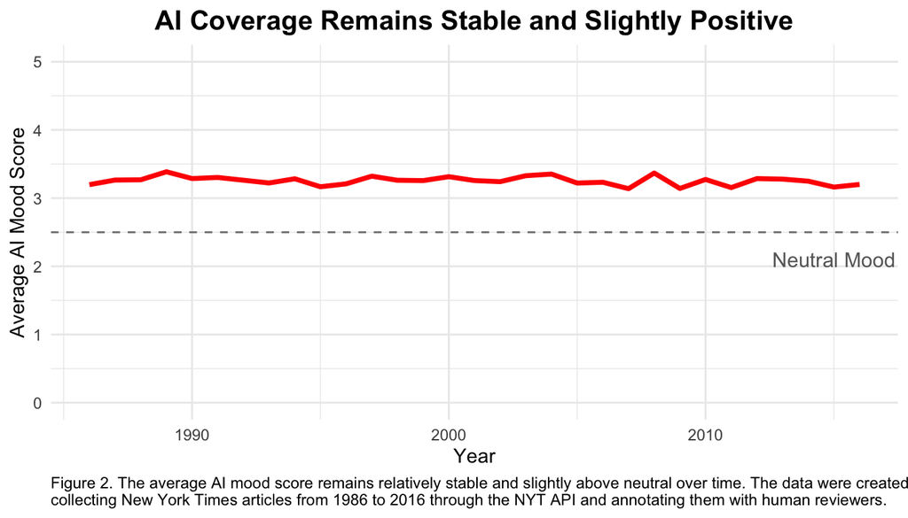

Figure 2 demonstrates the attitude shown in the paragraphs toward AI over time. It easy to see that the average AI mood score every year is relatively stable over time and slightly above neutral (around 3 to 3.5). Despite major technological advancements in AI over the past few decades, there is no clear upward or downward trend in the data. This suggests that The New York Times presents AI in a relatively balanced way, reflecting perspectives from both sides while maintaining a slightly positive tone. Such coverage helps readers develop a more overall understanding of AI rather than emphasizing only its risks or benefits.

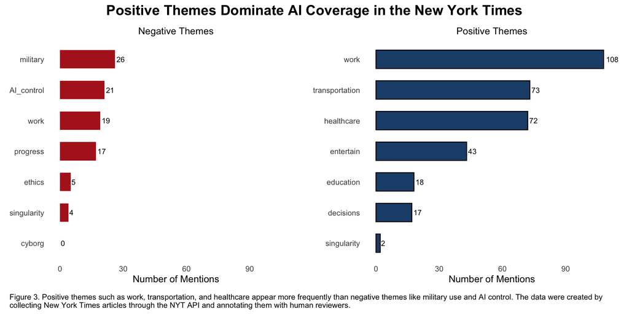

What causes this slightly positive trend? The Figure 3 of the types of concerns and hopes, along with their counts, help answer this question. Positive themes such as work, transportation, and healthcare appear much more frequently than negative concerns like military use and AI control (108, 73, 72 vs. 26, 21). This imbalance suggests that The New York Times emphasizes the potential benefits of AI more than its risks, contributing to an overall slightly positive portrayal of AI in its coverage.

### Overall Portrayal of AI in The New York Times

Overall, The New York Times presents AI in a stable and slightly positive way, with little change over time. It introduces more meaningful benefits such as in work, transportation, and healthcare than the negative concerns like military and ai-controlling. This kind of portrayal can help students to build a more balanced understanding of AI, allowing them to use AI wisely in their future lives.